# Informe Primer Semestre 2021

Artes Visuales y Tecnología

Claudio Rojas. Director Académico

2021-07-31

## 0.1 Presentación

El presente informe tiene como objetivo revisar el trabajo del sector, a través de información que sistematiza los resultados académicos del I semestre y recoge lo proyectado para el II semestre del presente año, considerando las definiciones claves que tenemos como colegio pero también como una institución de la Compañía de Jesús.

Este informe incluye:

- Definiciones Clases
- Informe de Notas
- Metas de Aprendizaje.
- Propuestas de Evaluación II Semestre.

Cada una de las partes de informe incluye sugerencias que bucan orientar la reflexión y práctica del sector para poder realizar los ajustes que sean necesarios para el trabajo de la segunda parte del presente año.

## 0.2 Definiciones Claves

Les recuerdo tener presente las definiciones claves tanto a nivel de red ignaciana como interna que deben siempre orientar nuestro trabajo académico.

### 0.2.1 Envío 3 Planificación Estratégica de los colegios Jesuitas

Asegurar que los 10 colegios y escuelas jesuitas desarrollen las prácticas y procesos necesarios para ofrecer la excelencia académica propia de una comprensión ignaciana de la educación de calidad.

### 0.2.2 Nuestra Definición de Calidad

Nosotros, como comunidad sanjavierina, entendemos por educación de calidad todo aprendizaje que nos lleva a descubrir y desarrollar nuestras capacidades de manera integral, formándonos como personas competentes, conscientes, comprometidas, compasivas y creativas, para así conocer y amar más y mejor a Jesucristo, sirviendo a nuestros hermanos en los diversos contextos sociales.

### 0.2.3 Nuestro Foco de Mejora

Fortalecer la propuesta curricular, con una didáctica renovada, bajo el Paradigma Pedagógico Ignaciano.

## 0.3 Informe de Notas

El informe de notas contiene la siguiente información:

- Tabla de Resumen de las notas por nivel.
- Notas de 1º básico a IVº medio.
- Distribución por Niveles de Logro.

En el caso de los resultados, les sugiero analizar:

- Los promedios finales obtenidos por cada nivel
- Cantidad de estudiantes que están en cada nivel de logro.
- Las diferencias de resultados entre hombres y mujeres.

### 0.3.1 Tabla de Resumen de Notas:

Estas tablas incluyen la información de cada asignatura por nivel:

- Promedio de la asignatura.
- Nota Mínima.
- Mediana.
- Nota Máxima.

#### 0.3.1.1 Tabla 1: Artes Visuales

[output not shown]

#### 0.3.1.2 Tabla 2: Tecnología

[output not shown]

### 0.3.2 Notas Artes Visuales

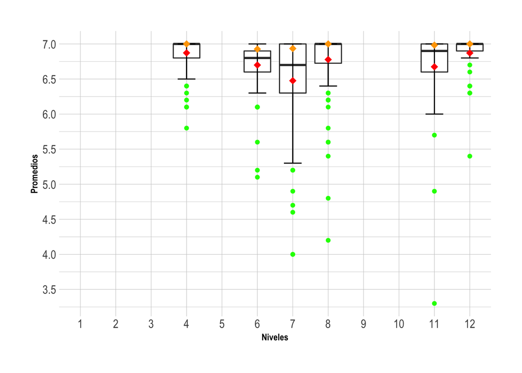

### 0.3.3 Notas de Tecnología

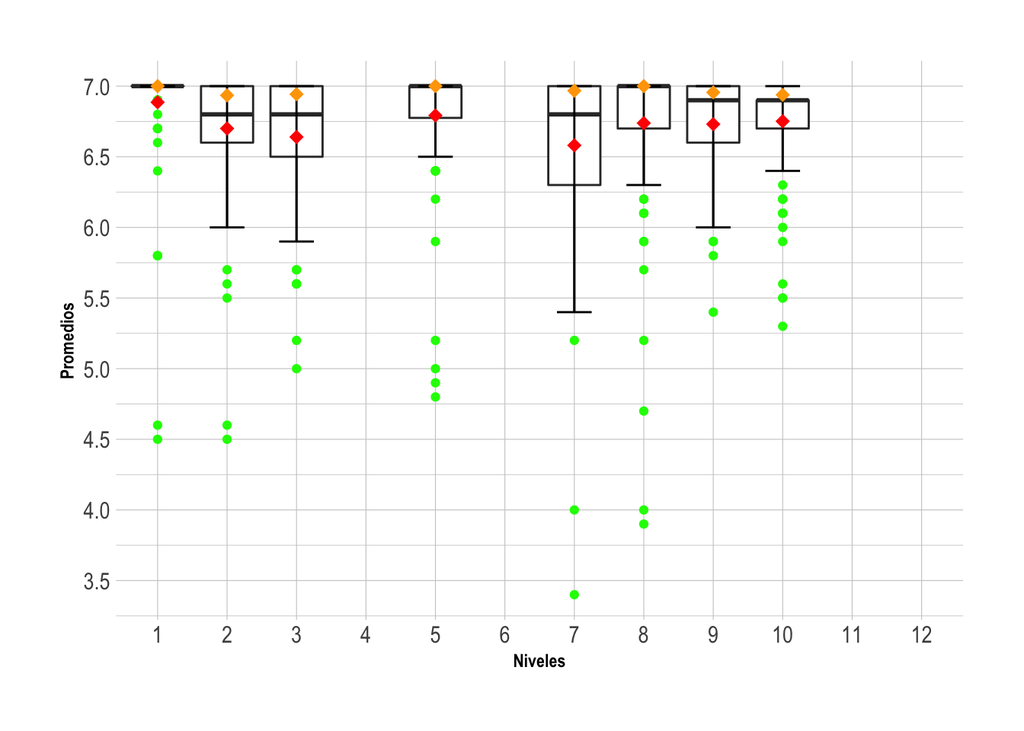

### 0.3.4 Distribución de Estudiantes por Niveles de Logro y diferenciado por Sexo.

#### 0.3.4.1 Primeros Básicos Tecnología

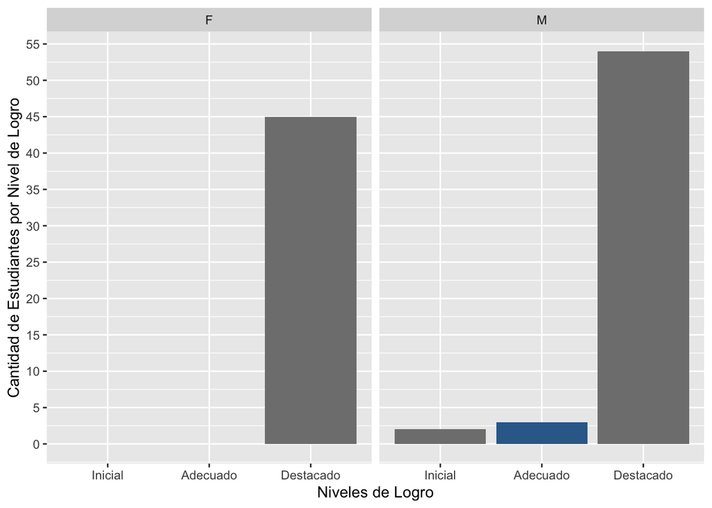

#### 0.3.4.2 Segundos Básicos Tecnología

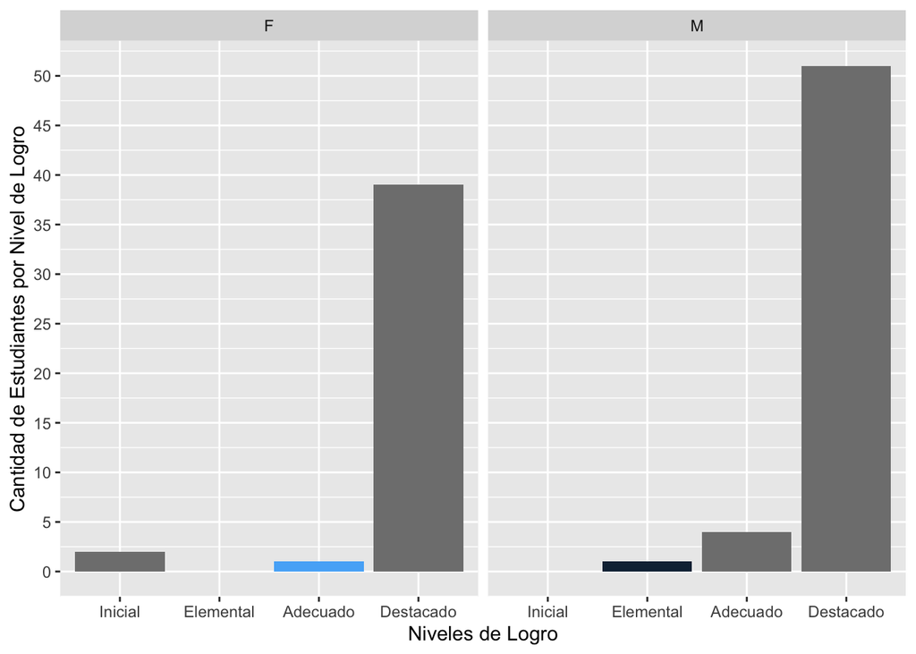

#### 0.3.4.3 Terceros Básicos

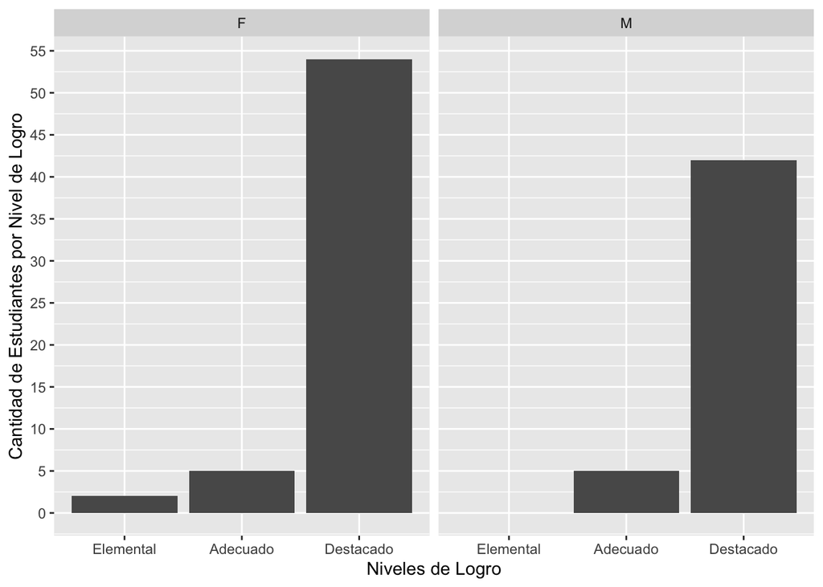

#### 0.3.4.4 Cuartos Básicos Artes

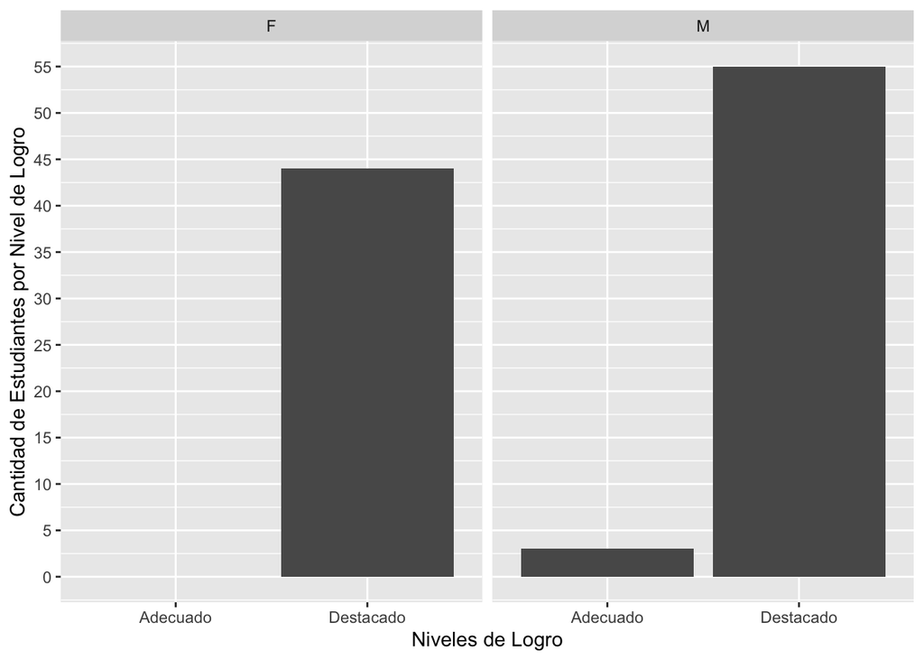

#### 0.3.4.5 Quintos Básicos Tecnología

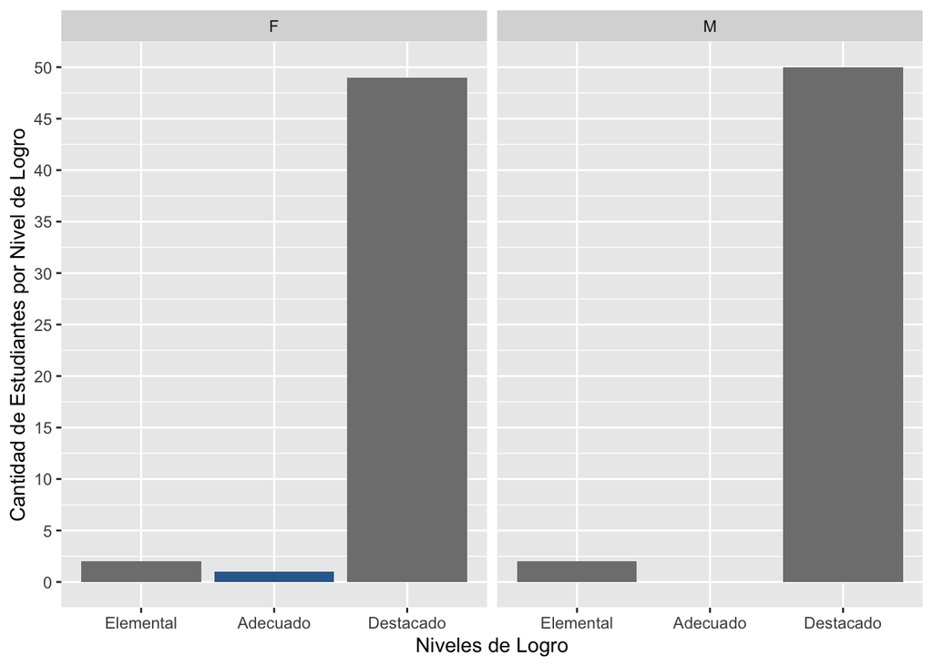

#### 0.3.4.6 Sextos Básicos Artes

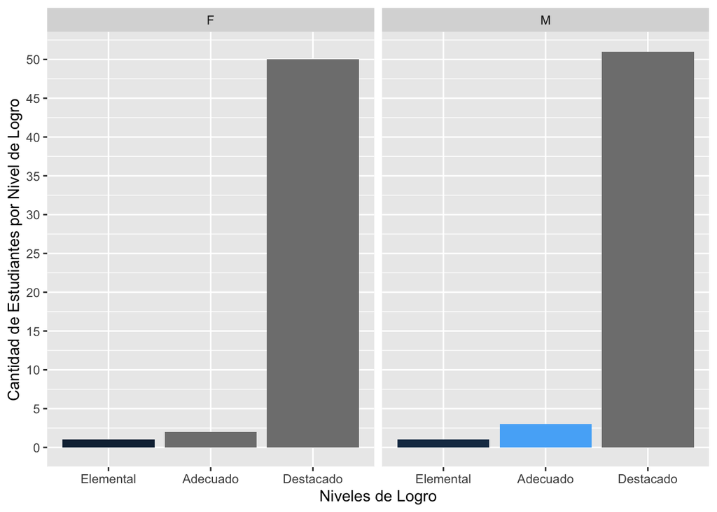

#### 0.3.4.7 Séptimos Básicos Artes

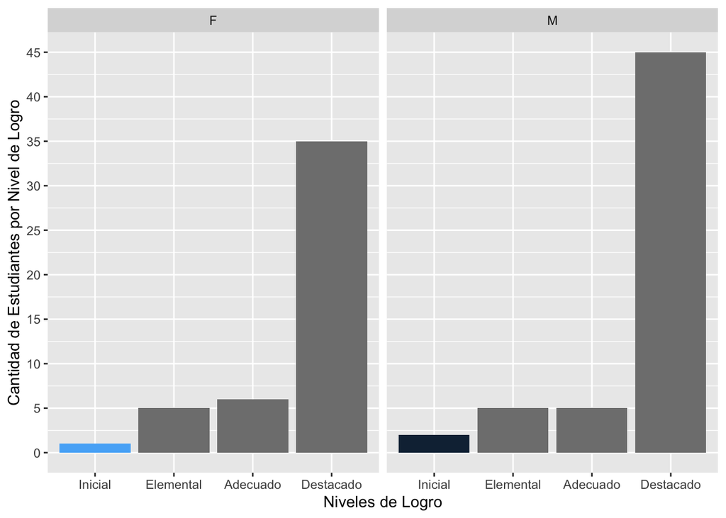

#### 0.3.4.8 Séptimos Básicos Tecnología

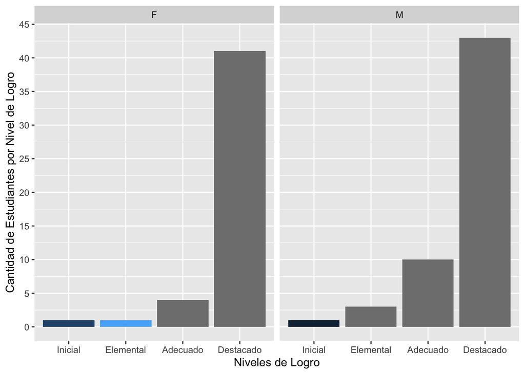

#### 0.3.4.9 Octavos Básicos Artes

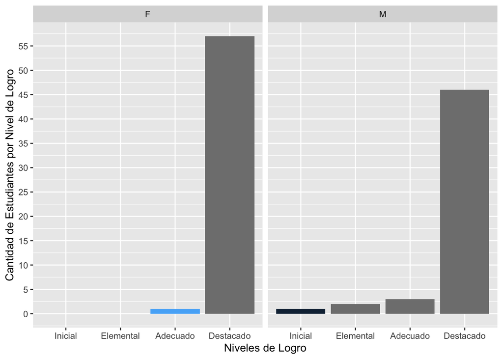

#### 0.3.4.10 Octavos Básicos Tecnología

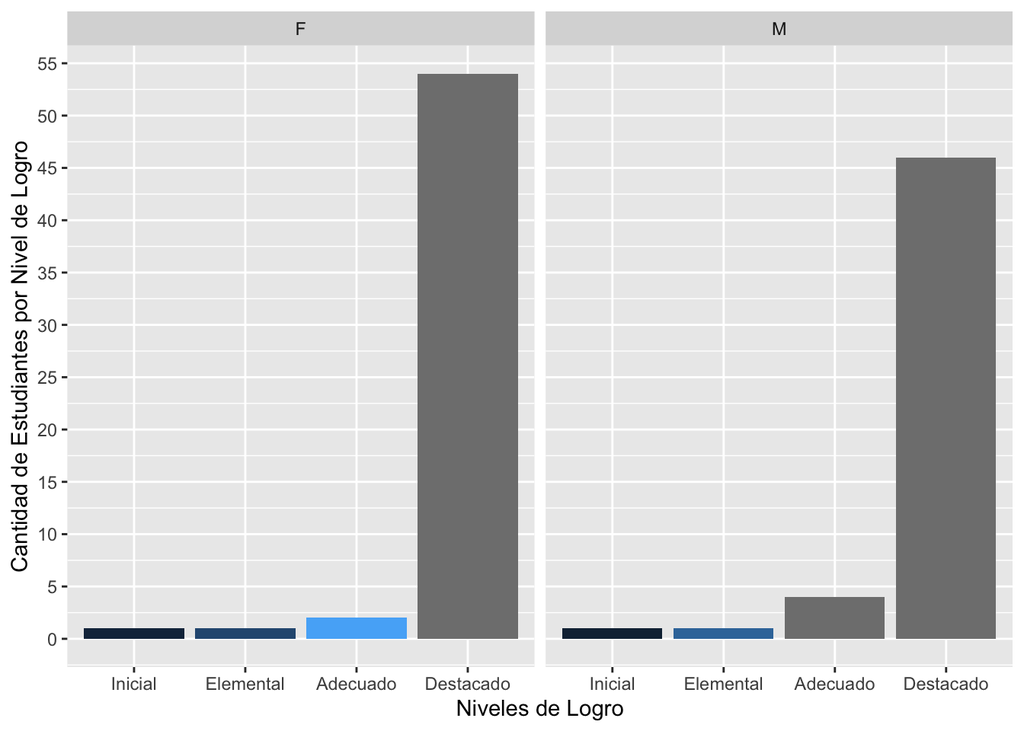

#### 0.3.4.11 Primeros Medios Tecnología

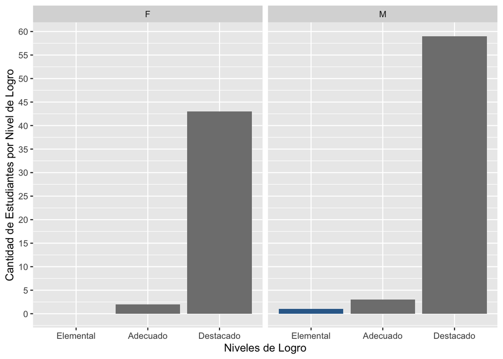

#### 0.3.4.12 Segundos Medios Tecnología

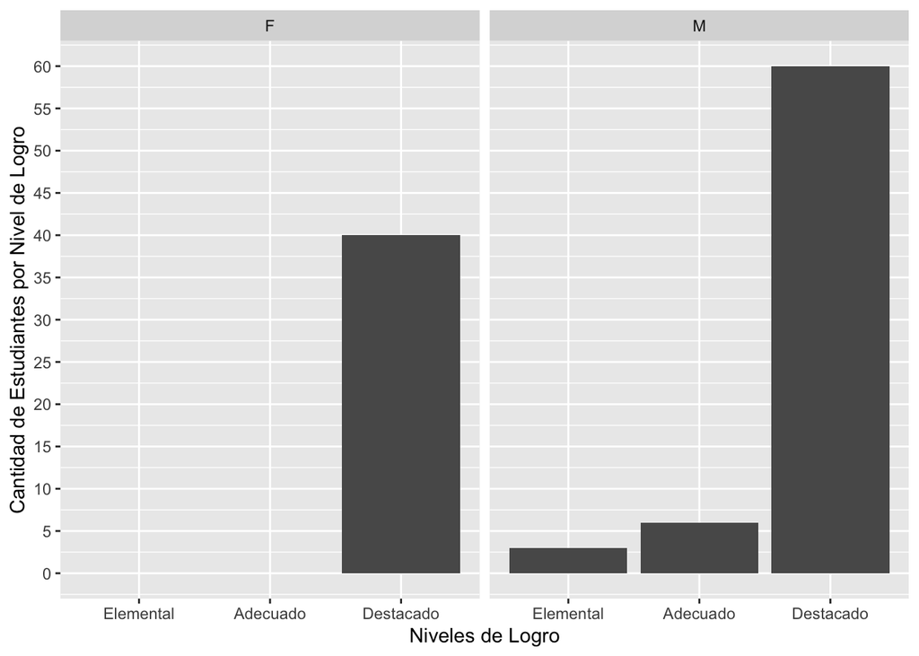

#### 0.3.4.13 Terceros y Cuartos Medios Artes

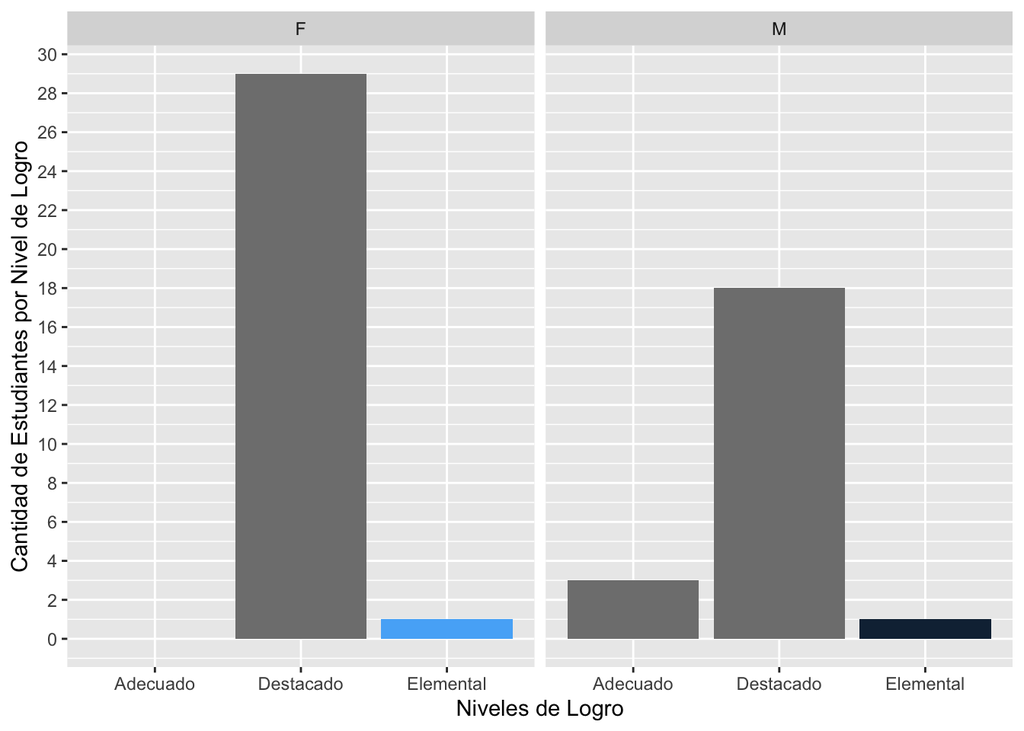

## 0.4 Metas de Aprendizajes

- **¿Contienen errores gramaticales:** **Redacción, Faltas de Ortografía** **?**
- **¿Están escritas de manera clara y precisa que permite** *evaluar (medible)***?**:

Ejemplo 1: *“Realicen esculturas y otras manifestaciones visuales acerca de temas relacionados al género. Para esto deberán realizar trabajos visuales basados en ideas que se originan a partir de la observación e investigación de manifestaciones visuales de diversas y variadas culturas. Justificando el o los propósitos expresivos en su creación personal como interpretar las creaciones de sus compañeros y compañeras”(Séptimo básico Artes)*. **En este caso, hay mezcla de la meta con el proceso. Corregir aquellas metas que sigan este patrón.**

Ejemplo 2:*“Analizar la interacción entre tecnología y sociedad, y desarrollar habilidades de pensamiento reflexivo y crítico” (Primero medio Tecnología)*. **En este caso, para lograr analizar se asume que se desarrollaron las habilidades reflexivas y criticas. Por ende, están dentro del proceso, no es necesario que vayan en la meta**.

Ejemplo 3 *“Se pretende sentar las bases para que los estudiantes desarrollen su capacidad crítica como usuarios, consumidores y productores acerca del avance tecnológico y sus efectos en la sociedad y el ambiente”(Segundo medio Tecnología)*. **No queda claro cuál es la meta sobre todo en como comienza: El sentar las bases**.

- **¿Se usan los verbos adecuados?** Ejemplo: *“Investigar, experimentar y crear proyectos multimediales, a partir de temas personales y desafíos creativos. Para esto podrán combinar medios de expresión tanto visuales como audiovisuales y sonoros, entre otros. También se busca que aprecien estéticamente y reflexionen acerca de manifestaciones multimediales de diferentes creadores y creadoras, las propias y las de sus pares, argumentando juicios críticos basándose en la selección de criterios pertinentes para el análisis estético”(Segundo medio Tecnología)*. **El verbo** *Crear* **es la meta, en cambio** *Investigar* **y** *Experimentar* **es parte del proceso que conduce a la meta. Por lo tanto, sugiero reescribir este tipo de metas**.
- **Revisar que las metas den cuenta de** *aprendizajes relevantes* **que deben adquirir mis estudiantes.**
- **Importante completar en los niveles donde no hay metas de artes o tecnología:** *Primero y Cuarto Básico*.
- **Ajustar las metas que contengan verbos que son poco precisos a la hora de medir:** *Comprender, Reflexionar*. **Pero también, aquellas que contengan verbos que den cuenta de niveles básicos de aprendizaje:** *Identificar, Reconocer, Describir*. **Las metas de aprendizajes deben ser** *Medibles* **pero también** *Desafiantes*.

### 0.4.1 Metas de Aprendizajes Primer Ciclo

| Nivel | Segunda Unidad | Tercera Unidad |
| --- | --- | --- |
| Primero Básico |  |  |
| Segundo básico Artes | Los estudiantes comunicarán a través de expresiones artísticas, obras vinculadas al proyecto de pueblos originarios. | Los estudiantes utilizan y crean textos instructivos para elaborar trabajos artísticos, utilizando distintas técnicas y materiales. |

### 0.4.2 Metas de Aprendizajes Segundo Ciclo

| Nivel | Segunda Unidad | Tercera Unidad |
| --- | --- | --- |
| Tercero básico Artes | Desarrollar su expresión y creatividad visual por medio de la elaboración de diferentes trabajos de Arte a partir de temas relacionados al entorno natural como flores, animales, observando referentes … |  |
| Cuarto básico |  |  |
| Quinto básico Artes | Progresar en habilidades de creación visual por medio de la realización de trabajos de Arte centrados en personajes y/o referentes. Obervación y apreciación de ejemplos y la utilización de diversos me… |  |
| Sexto básico Tecnología | Crear diseños innovadores de objetos o sistemas tecnológicos para aprovechar oportunidades o entregar soluciones a diversos problemas. |  |

| Nivel | Segunda Unidad | Tercera Unidad |
| --- | --- | --- |
| Séptimo básico Artes | Realicen esculturas y otras manifestaciones visuales acerca de temas relacionados al género. Para esto deberán realizar trabajos visuales basados en ideas que se originan a partir de la observación e … | Realizar pinturas, collages y objetos visuales, teniendo como referente percepciones, emociones e ideas provocadas por la apreciación de íconos sociales de diferentes épocas y culturas, especialmente … |
| Séptimo básico Tecnología | Elaborar objetos o sistemas innovadores, explorando en el entorno para aprovechar oportunidades o entregar soluciones al problema planteado. |  |
| Octavo básico Artes | Crear instalaciones a partir de temas propuestos por estudiantes o por el profesor, dónde logren justificar sobre sus propósitos y temas de interes y experimentar con diferentes materialidades, herram… |  |
| Octavo básico Tecnología | Diseñar un producto tecnológico respetando criterios de sustentabilidad y usando herramientas digitales. Comunicar el resultado del diseño utilizando aplicaciones de imagen, audio y video. |  |
| Primero medio Artes | Desarrollar trabajos y proyectos de diseño urbano y pintura mural, basados en temáticas personales y en la apreciación de diferentes tipos de pinturas y elementos de diseño urbano y mural. |  |
| Primero medio Tecnología | Analizar la interacción entre tecnología y sociedad, y desarrollar habilidades de pensamiento reflexivo y crítico. |  |

## 0.5 Plan de Evaluación IIº semestre 2021

En la siguiente tabla se presentan los procedimientos e instrumentos declarados tanto en Artes Visuales como en Tecnología y la cantidad de veces que se repiten. Revisar lo declarado en el plan de evaluación considerando los siguientes criterios:

- **¿Hay claridad en el sector entre lo que es un procedimiento y su diferencia con el instrumento?**. En el caso de dudas, revisar nuestro [Reglamento de Evaluación](https://www.colsanjavier.cl/files/documentos/REGLAMENTO%20INTERNO%20DE%20EVALUACIÓN%202021.%20%5Bv.%2030-04-2021%5D.pdf).
- **¿Existe una diversidad de formas de evaluar o se limitan a la práctica tradicional de procedimientos e instrumentos utilizados por sector?** Discutir en el sector si todos entienden lo mismo por: *“prototipo”, “investigación”, “trabajo”,“informe de avance”.*

Por último, se agrega una nube de palabras que quiere reflejar la diversidad de instrumentos y el peso de cada uno de ellos.

|  | word | freq |
| --- | --- | --- |
| trabajo | trabajo | 12 |
| tarea | tarea | 9 |
| informeavance | informeavance | 7 |
| investigación | investigación | 6 |
| prototipo | prototipo | 6 |
| proyecto | proyecto | 3 |
| final | final | 1 |
| presentación | presentación | 1 |

[interactive chart not shown]

En el caso del **Plan de Nivel**, les solicito que como sector concuerden y plasmen en la planificación

- En qué sesiones se evaluarán el OA que se hace responsable el sector.
- El instrumento que usarán para concretar esta evaluación.

Es importante que ustedes como jefes de sector hagan sequimiento de este proceso, ya que es el medio con el cual concretamos la formación integral. Pero, además, los resultados obtenidos, es lo que informamos a los estudiantes y sus familias en los distintos objetivos de aprendizajes asociados a las tres dimensiones de nuestro Mapa de Formación Integral.